# The Marriage Penalty: What the Data Really Shows

A Census Income Analysis

Derek Daly

2026-06-03

## The Setup

Working in restaurants, I heard a recurring theme from the men around me:

> *“Don’t get married, kid. Biggest mistake of my life.”*

This came up constantly—from customers, from coworkers, from managers. And plenty of other older men throughout my life… The narrative was clear: **marriage ruins your financial life.**

But is this actually true? Does the data support it?

## The Narrative

[figure not shown]

*“Don’t get married kid. Biggest mistake of my life.”*

## The Question

**Do married men actually earn less than never-married men?**

I analyzed 1994 U.S. Census data to investigate whether marriage is truly a “financial penalty” or just a story men tell themselves.

## The Data

```
Total male observations: 21790
```

```
Marital status breakdown:
```

```
             Divorced     Married-AF-spouse    Married-civ-spouse
                 1771                     9                 13319
Married-spouse-absent         Never-married             Separated
                  213                  5916                   394
              Widowed
                  168
```

## The Heatmap: Marriage & Income by Education

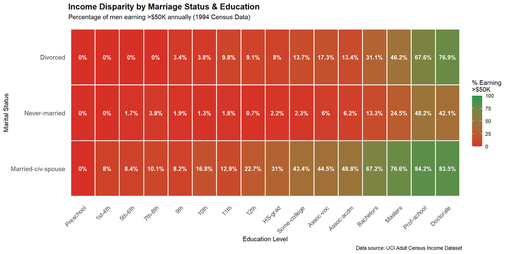

## Key Statistics

```
Married men earning >$50K:       44.6 %
```

```
Never-married men earning >$50K: 5.5 %
```

```
Divorced men earning >$50K:      16 %
```

```
Chi-square p-value: 0e+00
```

```
Result: HIGHLY SIGNIFICANT (p < 0.001)
```

```
Married men avg hours/week:       44.1
```

```
Never-married men avg hours/week: 38.5
```

## What the Heatmap Reveals

- **The opposite of the narrative**: Married men actually earn MORE than never-married men across almost every education level.
- **Education is the real divider**: A Doctorate or Masters degree dramatically increases earning potential regardless of marital status.
- **The married advantage**: At the bachelor’s level, married men have a substantial income edge over never-married men.
- **Selection effects**: Older, more established men are more likely to be married AND earn more.

## The Conclusion

**The men at the restaurant were wrong — or at least, misleading.**

The data shows:

- ✅ Married men earn MORE, not less
- ✅ The “marriage penalty” is a myth
- ✅ What REALLY matters is education and job choice

The actual story: these men felt constrained by family responsibilities and financial pressure. But that’s not a marriage penalty — that’s life stage and occupation.

## References

- **Data Source**: UCI Machine Learning Repository — Adult Census Income Dataset
- **Original Citation**: Kohavi, R. (1996). Scaling Up the Accuracy of Naive-Bayes Classifiers. KDD Proceedings.
- **Sample Size**: 21,790 male workers from 1994 U.S. Census
- **AI assistance was used to help generate the R code and/or debug R code. All submitted R codewas reviewed, modified, and understood by me, the author.**